# Zápočtový test 1

# Zápočtový test 1

## 1. Část - Úlohy na interpretaci výstupů

### Úloha 1

Která z číselných proměnných má nejvíce asymetrické rozdělení? O jakou asymetrii se jedná? Podle čeho tak usuzujete? A jak je to se špičatostí proměnné?

*Proměnná Rank (Skew = 1.9078128 … hodnota je nejvzdálenější od nuly ze všech proměnných). Jedná se o pozitivní zešikmení. Usuzuji z hodnot šikmosti všech číselných proměnných, potvrzeno histogramem. U proměnné Rank je rozdělení z hlediska špičatosti leptokurtické - kolem modusu se nachází spoustu hodnot, ale také je zde plno odlehlejších hodnot.*

### Úloha 2

Souvisí spolu průměrné skóre testů z matematiky a výsledek rozřazovacího testu? (Proměnné GPAadj a PlcmtScore)? Pokud ano, jedná se o souvislost silnou nebo slabou, přímou nebo nepřímou? Na základě čeho tak usuzujete?

*Z korelační matice lze vyčíst, že korelační koeficient r těchto dvou proměnných je roven 0.5651063. Z toho lze usoudit, že spolu tyto dvě proměnné souvisí. Jde o středně silnou souvislost, spíše se blíží k silné souvislosti. Jde o přímou souvislost, tudíž čím větší bylo skóre z testu z matematiky, tím větší bylo skóre z rozřazovacího testu daného studenta a naopak. Vše usuzuji z korelační matice a hodnoty korelačního koeficientu.*

### Úloha 3

Najděte a interpretujte 80%-ní kvantil výsledku výstupního testu (Proměnná Grade).

*80%-ní kvantil odpovídá známce B. Tudíž 80% studentů dostalo známku B nebo lepší. Přesněji 96,39%.*

### Úloha 4

Porovnejte rozložení hodnot SAT skóre z matematiky a výsledků rozřazovacího testu, proměnné SATM a PlcmtScore. Porovnejte jak počty bodů, jichž studenti v obou testech dosahovali, tak variabilitu i tvar rozdělení obou proměnných.

- Počet bodů:
  - *Velký rozdíl v průměru - SATM: 64.1, PlcmtScore: 38.9 , což naznačuje, že studenti dosahují vyššího skóre z testu z matematiky než z rozřazovacího testu.*
  - *minimum, maximum - SATM má celkově lepší výsledky, se značně větším minimálním i maximálním počtem bodů*
  - *IQR - mezera mezi kvartily je širší u rozřazovacího testu, což naznačuje vyšší variabilitu v rozdělení výsledků*
- Variabilita:
  - *Výsledky rozřazovacího testu jsou rozptýlenější než u SATM. - lze usoudit po srovnání hodnot SD a MAD*
  - *Rozřazovací test má vyšší variační koeficient než SATM. Lze tedy usoudit, že v testu SATM studenti dosahují podobnějších výsledků*
- Tvar rozdělení:
  - *Oba výsledky testů mají negativní zešikmení, SATM je šikmější, ale rozdíl není velký.*
  - *Oba výsledky testů jsou platykurticky rozděleny z hlediska špičatosti - tedy ploššeji než normální rozdělení. Zde je plošnost u rozřazovacího testu výrazně větší než u SATM.*

### Úloha 5

*Proměnná Size je unimodální - má jeden modus. Nejčastěji tedy psal student test ve třídě o 450 - 500 studentech.*

### Úloha 6

Do jaké míry se studenti řídili doporučením, jak obtížný kurz si mají volit? A ti, co se neřídili, volili spíše těžší nebo lehčí kurzy, než jim bylo doporučeno? (Využijte proměnné RecTaken, TooHigh a TooLow).

## 2. Část - Úlohy na popisnou a inferenční statistiku

```r
load("/Users/majdikleckerova/Desktop/!sample_zapocet_test_202324/Math.RData")
```

### Úloha 1

Spočtěte a interpretujte 95%-ní interval spolehlivosti pro počet žáků ve třídě (Proměnná Size).

```r
library(DescTools)
MeanCI(Math$Size, method="classic", conf.level = 0.95, sides="two.sided")
```

```
    mean   lwr.ci   upr.ci
341.6627 307.9879 375.3374
```

### Úloha 2

Je statisticky významný rozdíl ve střední hodnotě PSAT skóre z matematiky mezi těmi, co si zvolili těžší kurz, než byl pro ně doporučený a těmi, co tak neučinili? Pracujte s proměnnými PSATM a TooHigh.

```r
library(tidyverse)
stredni_hodnoty <- Math %>% group_by(TooHigh) %>%
  summarize(stredni_hodnota = mean(PSATM, na.rm=TRUE))
```

*Střední hodnota těch, co si zvolili těžší kurz = 59.47826, těch, co ne = 63.80000. Skóre se pohybovala v rozmezí 47 - 80 bodů, takže se zdá, že rozdíl není významný. Pojďme ověřit t-testem.*

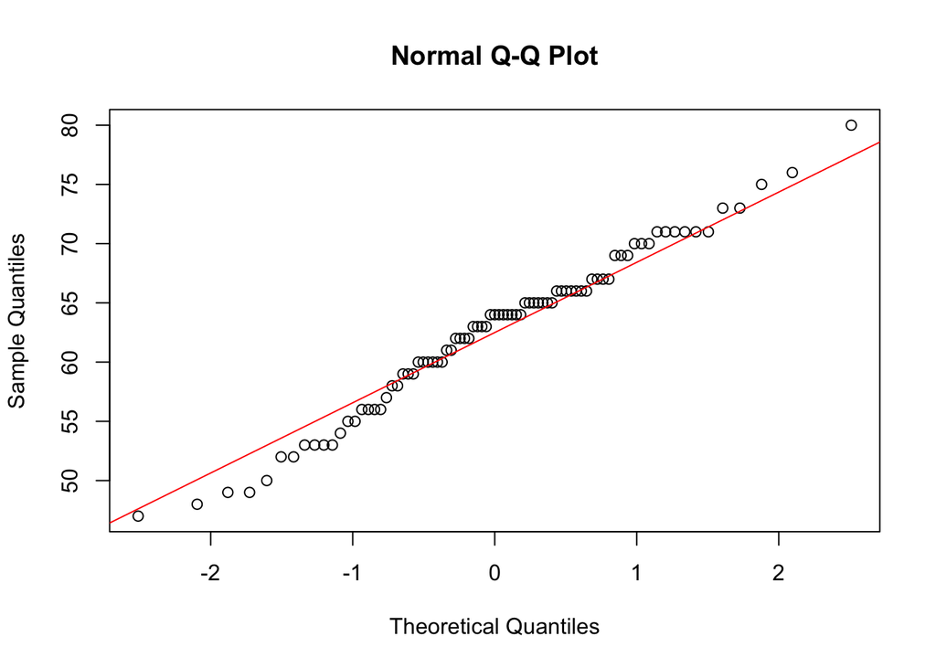

```r
qqnorm(Math$PSATM)
qqline(Math$PSATM, col = "red")
```

```r
shapiro.test(Math$PSATM)
```

```
    Shapiro-Wilk normality test

data:  Math$PSATM
W = 0.98338, p-value = 0.3611
```

```r
# normální rozdělení - můžeme použít t.test
```

*Nulová hypotéza: Mezi průměry není rozdíl*

```r
t.test(PSATM~TooHigh, data = Math)
```

```
    Welch Two Sample t-test

data:  PSATM by TooHigh
t = 2.4316, df = 34.015, p-value = 0.02045
alternative hypothesis: true difference in means between group 0 and group 1 is not equal to 0
95 percent confidence interval:
 0.7097884 7.9336899
sample estimates:
mean in group 0 mean in group 1
       63.80000        59.47826
```

*Zamítáme nulovou hypotézu (p-value < 0.05) -> Mezi hodnotami je skutečný statistický rozdíl.*

### Úloha 3

Má průměrné skóre z matematických testů (GPAadj) odlehlá pozorování? Jaký postup byste při určování odlehlých hodnot u této proměnné zvolili a proč?

*Proměnná je diskrétní, tudíž je nejvhodnější zjistit počet četností jednotlivých výsledků a najít hodnoty, co vyčnívají.*

```r
mean(Math$GPAadj)
```

```
[1] 37.63855
```

```r
table(Math$GPAadj)
```

```
29 30 31 32 33 34 35 36 37 38 39 40
 1  1  2  3  2  2  4  6 11  9 12 30
```

*Vyčnívají hodnoty skóre 29 a 30, jsou to kandidáti na odlehlé hodnoty.* *Z-Skóre - ale to je lepší použít když jde o normální rozdělení, což u nás není*

```r
scores <- 29:40
frequencies <- c(1, 1, 2, 3, 2, 2, 4, 6, 11, 9, 12, 30)
data <- rep(scores, frequencies)
mean_val <- mean(data)
sd_val <- sd(data)
z_scores <- (data - mean_val) / sd_val
outliers <- data[abs(z_scores) > 3]
outliers
```

```
[1] 29
```

*IQR, nevyžaduje normální rozdělení*

```r
Q1 <- quantile(Math$GPAadj, 0.25)
Q3 <- quantile(Math$GPAadj, 0.75)
IQR <- Q3 - Q1

lower_bound <- Q1 - 1.5 * IQR
upper_bound <- Q3 + 1.5 * IQR

# Identifikace odlehlých hodnot
outliers <- Math$GPAadj[Math$GPAadj < lower_bound | Math$GPAadj > upper_bound]
outliers
```

```
[1] 30 29 31 31
```

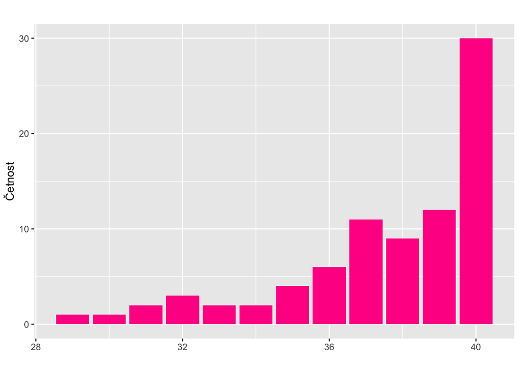

```r
Math %>%
  ggplot(aes(x = GPAadj)) +
  geom_bar(fill = "deeppink") +
  labs(title = "", x = "", y = "Četnost") +
  theme(plot.title = element_text(face = "bold"))
```

*Závěr: odlehlá hodnota je jistě hodnota skóre 29, a možné odlehlé hodnoty jsou 30 a 31.*

# 3. Část - Úlohy na pravděpodobnostní rozdělení

## Úloha 1

Doma mám 8 hrníčků, z nichž 3 jsou zelené a zbytek žlutých. Každý večer je všechny umyji, aby byly připravené na ráno. Ráno jeden z těchto osmi náhodně vyberu a uvařím si do něj čaj. Jaká je pravděpodobnost, že v jednom týdnu (7 dní) budu pít ze žlutého hrníčku 5krát a více?

*Binomické - opakovaný výběr* **size** = 7 … počet pokusů (7 dní) **prob** = 5/8 … pravděpodobnost úspěchu v jednom pokusu

```r
round((1 - pbinom(4, size = 7, prob = 5/8)),3)
```

```
[1] 0.475
```

## Úloha 2

IQ je standardní škála, která má v populaci **normální rozdělení** se střední hodnotou **100** a rozptylem **225**. Jaká je pravděpodobnost, že:

```r
mean <- 100
sd <- sqrt(225)
```

1. Hodnota IQ náhodně vybrané osoby bude nižší než **85**?

```r
round(pnorm(85, mean = mean, sd = sd),3)
```

```
[1] 0.159
```

2. Náhodně vybraná osoba bude moci vstoupit do organizace Mensa Česko, je-li dolní hranice IQ pro vstup **130**?

```r
round((1 - pnorm(130, mean = mean, sd = sd)),3)
```

```
[1] 0.023
```

3. Hodnota IQ náhodně vybrané osoby bude v rozsahu **110-125**?

```r
round((pnorm(125, mean = mean, sd = sd) - pnorm(110, mean = mean, sd = sd)),3)
```

```
[1] 0.205
```

4. Když náhodně potkám dvě osoby, budou mít obě IQ menší než **100**?

```r
round((pnorm(100, mean = mean, sd = sd) * pnorm(100, mean = mean, sd = sd)),3)
```

```
[1] 0.25
```